# D213 Task 2

Nicholas Hurd

2024-03-24

```r
library(magrittr)
library(dplyr)
library(tidytext)
library(neuralnet)
library(keras)
library(tensorflow)
library(tidyverse)
library(reticulate)
library(ggplot2)
library(purrr)
library(caret)
library(tm)
library(reshape2)
```

```r
imdb <- read.csv("C:/Users/nahur/Desktop/WGU/D213 Advanced Data Analytics/Task 2/Datasets/sentiment labelled sentences/imdb_labelled.txt", quote = "", header = F, sep = "\t")
amazon <- read.csv("C:/Users/nahur/Desktop/WGU/D213 Advanced Data Analytics/Task 2/Datasets/sentiment labelled sentences/amazon_cells_labelled.txt", quote = "", header = F, sep = "\t")
yelp <- read.csv("C:/Users/nahur/Desktop/WGU/D213 Advanced Data Analytics/Task 2/Datasets/sentiment labelled sentences/yelp_labelled.txt", quote = "", header = F, sep = "\t")
```

```r
imdb <- imdb %>%
  rename(review = V1, score = V2)

amazon <- amazon %>%
  rename(review = V1, score = V2)

yelp <- yelp %>%
  rename(review = V1, score = V2)

combined_data <- rbind(yelp, amazon)
combined_data <- rbind(combined_data, imdb)
```

## **Part I: Research Question**

#### A

##### 1.

Using previous user reviews, can we predict a user’s opinion on a product or service as either positive or negative?

##### 2.

The goal of this analysis is to identify patterns of language from user reviews to accurately predict a user’s opinion on a product or service. The review data will have to be preprocessed in a way to extract relevant features. The model will be trained on the historical data to predict user sentiment. The performance of the model will be evaluated for accuracy.

## **Part II: Data Preparation**

#### B.

##### 1.

```r
summary(combined_data) # Summary of data
```

```
##     review              score
##  Length:3000        Min.   :0.0
##  Class :character   1st Qu.:0.0
##  Mode  :character   Median :0.5
##                     Mean   :0.5
##                     3rd Qu.:1.0
##                     Max.   :1.0
```

```r
combined_data <- combined_data[!duplicated(combined_data, fromLast = TRUE), ] # Remove duplicates, keep first occurrence
sum(duplicated(combined_data)) # Verify there are no duplicates
```

```
## [1] 0
```

```r
colSums(is.na(combined_data)) # Checking for NA
```

```
## review  score
##      0      0
```

```r
is.null(combined_data) # Checking for NULL
```

```
## [1] FALSE
```

```r
# Unusual characters and emjois
# Remove non-alphanumeric characters from strings
strsplit(combined_data$review, "[^a-zA-Z0-9]+")

# Make everything lowercase
combined_data$review <- tolower(combined_data$review)

# Remove punctuation
combined_data$review <- gsub("[[:punct:]]", "", combined_data$review)
head(combined_data$review)

# Address Emojis
row_with_emojis <- grepl("[\U{1F600}-\U{1F64F}\U{2702}-\U{27B0}\U{1F680}-\U{1F6C0}\U{1F170}-\U{1F251}\U{1F004}\U{1F0CF}\U{1F004}\U{1F004}]", combined_data$review, perl = TRUE)
sum(row_with_emojis)
```

```r
head(combined_data$review)
```

```
## [1] "wow loved this place"
## [2] "crust is not good"
## [3] "not tasty and the texture was just nasty"
## [4] "stopped by during the late may bank holiday off rick steve recommendation and loved it"
## [5] "the selection on the menu was great and so were the prices"
## [6] "now i am getting angry and i want my damn pho"
```

```r
# Vocabulary Size
# Character/word count
combined_data$review %>%
  strsplit(" ") %>%
  sapply(length) %>%
  summary()
```

```
##    Min. 1st Qu.  Median    Mean 3rd Qu.    Max.
##    1.00    6.00   11.00   12.21   17.00   72.00
```

```r
tidy_combined_data <- combined_data %>%
  unnest_tokens(word, review)

vocab_size <- tidy_combined_data %>%
  count(word) %>%
  nrow()
cat("Vocabulary Size:", vocab_size)
```

```
## Vocabulary Size: 5398
```

```r
# Sentence Lengths
sent_length <- sapply(strsplit(combined_data$review, "\\s+"), length)
summary(sent_length)
```

```
##    Min. 1st Qu.  Median    Mean 3rd Qu.    Max.
##    1.00    6.00   10.00   11.83   16.00   70.00
```

```r
# Word Embedding Length
max_seq_embed <- as.integer(round(sqrt(sqrt(vocab_size)), 0))
max_seq_length <- max(sent_length)
med_seq_length <- median(sent_length)
min_seq_length <- min(sent_length)
cat("Estimated Embedding Length:", max_seq_embed,
    "\nMaximum Sequence Length:", max_seq_length,
    "\nMedian Sequence Length:", med_seq_length,
    "\nMinimum Sequence Length:", min_seq_length)
```

```
## Estimated Embedding Length: 9
## Maximum Sequence Length: 70
## Median Sequence Length: 10
## Minimum Sequence Length: 1
```

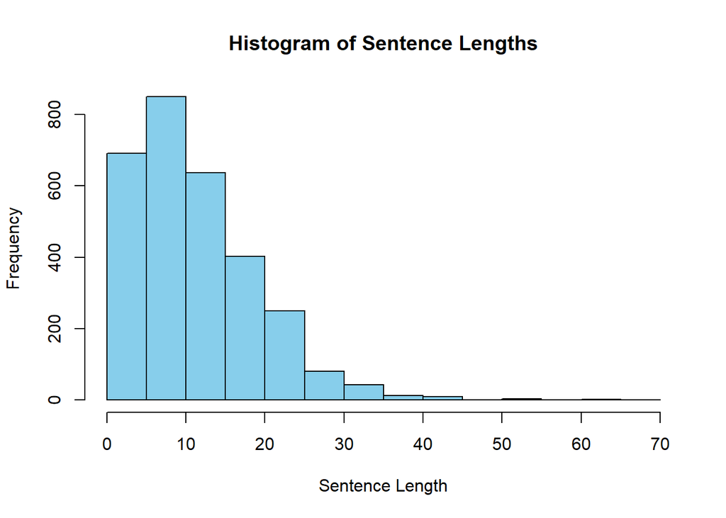

```r
hist(sent_length,
     main = "Histogram of Sentence Lengths",
     xlab = "Sentence Length",
     ylab = "Frequency",
     col = "skyblue",
     border = "black")
```

##### 2.

The purpose of tokenization is to separate the sentences and texts into smaller individual pieces or tokens. Each word is assigned a “word index” for the model to use during the training process (Elleh, 2022). The model learns the relationships between the tokens and responses are generated based on the learned patterns (McKinsey and Co, 2024).

The function unnest_tokens() is used on the ‘review’ column in the ‘tidy_combined_data’ dataset. This splits each review into individual tokens. All words are converted to lowercase and all punctuation is removed. Each word is stemmed to reduce the words to their root form. The function text_tokenizer() creates a tokenizer object and fits the tokenizer on the text data. This converts the words to a sequence of integers.

```r
tidy_combined_data <- combined_data %>%
  unnest_tokens(word, review)

tidy_combined_data <- tidy_combined_data %>%
  mutate(word = tolower(word),
         word = removePunctuation(word),
         word = stemDocument(word))
head(tidy_combined_data)
```

```
##   score  word
## 1     1   wow
## 2     1  love
## 3     1  this
## 4     1 place
## 5     0 crust
## 6     0    is
```

```r
tokenizer <- text_tokenizer()
tokenizer$fit_on_texts(tidy_combined_data$word)
word_indicies <- tokenizer$texts_to_sequences(tidy_combined_data$word)
```

##### 3.

Padding is a technique that assures the input data is the exact size and shape that the model expects. Additional elements are added to the input data to make it meet the model’s specifications, this process is called padding (Nanos, 2023). In my dataset, each sentence can have a different length of words so zeros are added to make all the input sentences the same size. The sequences of integers representing the words in the text data is stored in ‘word_indicies’. The padding occurs after the text sequence, as instructed by the ‘padding = “post”’ condition.

```r
padded_seq <- pad_sequences(word_indicies, maxlen = max_seq_length, padding = "post", truncating = "post")
```

```r
# Single Padded Sequence
single_pad_seq_index <- 8
single_pad_seq <- padded_seq[single_pad_seq_index,]
single_pad_seq
```

```
##  [1] 18  0  0  0  0  0  0  0  0  0  0  0  0  0  0  0  0  0  0  0  0  0  0  0  0
## [26]  0  0  0  0  0  0  0  0  0  0  0  0  0  0  0  0  0  0  0  0  0  0  0  0  0
## [51]  0  0  0  0  0  0  0  0  0  0  0  0  0  0  0  0  0  0  0  0
```

##### 4.

There are two categories of sentiment, positive and negative. The activation function for the final dense layer of the network will be ‘sigmoid’. The sigmoid is useful for binary classification because it maps the input values to a value of 0 and 1 (Vishwakarma, 2023).

```r
text_vectorization <- layer_text_vectorization(
  max_tokens = vocab_size,
  output_sequence_length = max_seq_length,
)

text_vectorization %>% adapt(combined_data$review)

text_vectorization(matrix(combined_data$review[1], ncol = 1))
```

```
## tf.Tensor(
## [[640 213   9  40   0   0   0   0   0   0   0   0   0   0   0   0   0   0
##     0   0   0   0   0   0   0   0   0   0   0   0   0   0   0   0   0   0
##     0   0   0   0   0   0   0   0   0   0   0   0   0   0   0   0   0   0
##     0   0   0   0   0   0   0   0   0   0   0   0   0   0   0   0]], shape=(1, 70), dtype=int64)
```

```r
text_vectorization(matrix(combined_data$review))
```

```
## tf.Tensor(
## [[ 640  213    9 ...    0    0    0]
##  [2030    6   15 ...    0    0    0]
##  [  15  403    3 ...    0    0    0]
##  ...
##  [  12    5  573 ...    0    0    0]
##  [4413   50    0 ...    0    0    0]
##  [  34   12   34 ...    0    0    0]], shape=(2983, 70), dtype=int64)
```

```r
input_layer <- layer_input(shape = c(1), dtype = "string")
output <- input_layer %>%
  text_vectorization() %>%
  layer_embedding(input_dim = vocab_size + 1, output_dim = 16) %>%
  layer_global_average_pooling_1d() %>%
  layer_dense(units = 16, activation = "relu") %>%
  layer_dropout(0.5) %>%
  layer_dense(units = 1, activation = "sigmoid")
```

##### 5.

After importing each data source, I combined them into one dataset. To prepare the data I checked and removed any duplicates, and checked for nulls and NA values. Then I checked for unusual characters, punctuation, and any other non-alphanumeric characters. The vocabulary size, sentence lengths, and word embedding lengths were established. The text was split into tokens using unnest_tokens(). Padding was required to make the input data the same shape for the model and was achieved using pad_sequences(). The input layer was constructed to receive the raw input data and pass it forward and the output layer was constructed to create the final predictions based on the processed input data. The final step in preparing the data for analysis was splitting the data. The data was split into three parts; training (60%), testing (20%), and validation (20%).

```r
# Split data
set.seed(123)

  # Define proportions for train, validation, and test sets
train_split <- 0.6
validation_split <- 0.2
test_split <- 0.2

  # Determine the number of samples for each split
num_samples <- nrow(tidy_combined_data)
num_train <- round(train_split * num_samples)
num_validation <- round(validation_split * num_samples)
num_test <- num_samples - num_train - num_validation

  # Split the data into train, validation, and test sets
train_data <- tidy_combined_data[1:num_train, ]
validation_data <- tidy_combined_data[(num_train + 1):(num_train + num_validation), ]
test_data <- tidy_combined_data[(num_train + num_validation + 1):(num_train + num_validation + num_test), ]
```

## **Part III: Network Architecture**

##### 1.

```r
model <- keras_model(input_layer, output)
summary(model)
```

```
## Model: "model"
## _____________________________________________________________________
## Layer (type)                   Output Shape               Param #
## =====================================================================
## input_1 (InputLayer)           [(None, 1)]                0
## _____________________________________________________________________
## text_vectorization (TextVector (None, 70)                 0
## _____________________________________________________________________
## embedding (Embedding)          (None, 70, 16)             86384
## _____________________________________________________________________
## global_average_pooling1d (Glob (None, 16)                 0
## _____________________________________________________________________
## dense_1 (Dense)                (None, 16)                 272
## _____________________________________________________________________
## dropout (Dropout)              (None, 16)                 0
## _____________________________________________________________________
## dense (Dense)                  (None, 1)                  17
## =====================================================================
## Total params: 86,673
## Trainable params: 86,673
## Non-trainable params: 0
## _____________________________________________________________________
```

##### 2.

```r
model %>% compile(
  loss = "binary_crossentropy",
  optimizer = "adam",
  metrics = list('accuracy')
)

history <- model %>% fit(
  train_data$word,
  as.numeric(train_data$score == "1"),
  epochs = 15,
  batch_size = 32,
  validation_split = 0.2,
  callbacks = c(
    callback_early_stopping(monitor = "val_loss",
                            patience = 3,
                            mode = "auto",
                            restore_best_weights = TRUE)),
  verbose = 2
)
```

```
## 529/529 - 3s - loss: 0.6926 - accuracy: 0.5190 - val_loss: 0.6914 - val_accuracy: 0.5298
## 529/529 - 1s - loss: 0.6923 - accuracy: 0.5205 - val_loss: 0.6920 - val_accuracy: 0.5298
## 529/529 - 1s - loss: 0.6921 - accuracy: 0.5205 - val_loss: 0.6911 - val_accuracy: 0.5298
## 529/529 - 1s - loss: 0.6918 - accuracy: 0.5205 - val_loss: 0.6911 - val_accuracy: 0.5298
## 529/529 - 1s - loss: 0.6908 - accuracy: 0.5205 - val_loss: 0.6898 - val_accuracy: 0.5298
## 529/529 - 1s - loss: 0.6889 - accuracy: 0.5335 - val_loss: 0.6875 - val_accuracy: 0.5380
## 529/529 - 1s - loss: 0.6822 - accuracy: 0.5605 - val_loss: 0.6843 - val_accuracy: 0.5532
## 529/529 - 1s - loss: 0.6759 - accuracy: 0.5674 - val_loss: 0.6806 - val_accuracy: 0.5569
## 529/529 - 1s - loss: 0.6709 - accuracy: 0.5730 - val_loss: 0.6777 - val_accuracy: 0.5584
## 529/529 - 1s - loss: 0.6625 - accuracy: 0.5904 - val_loss: 0.6759 - val_accuracy: 0.5591
## 529/529 - 1s - loss: 0.6600 - accuracy: 0.5977 - val_loss: 0.6754 - val_accuracy: 0.5588
## 529/529 - 1s - loss: 0.6568 - accuracy: 0.6024 - val_loss: 0.6742 - val_accuracy: 0.5595
## 529/529 - 1s - loss: 0.6518 - accuracy: 0.6027 - val_loss: 0.6731 - val_accuracy: 0.5610
## 529/529 - 1s - loss: 0.6509 - accuracy: 0.6082 - val_loss: 0.6733 - val_accuracy: 0.5595
## 529/529 - 1s - loss: 0.6478 - accuracy: 0.6159 - val_loss: 0.6731 - val_accuracy: 0.5612
```

```r
# Number of parameters
output_dim <- 16
dense_units <- 16

params_embedding <- (vocab_size + 1) * output_dim # Embedding Layer
params_dense <- (output_dim + 1) * dense_units # Dense Layer
params_output <- dense_units + 1 # Output Layer

total_params <- params_embedding + params_dense + params_output
print(total_params)
```

```
## [1] 86673
```

There are seven layers in this neural network. There is one input layer, text preprocessing layer, one embedding layer, one global average pooling layer, one dense layer, one dropout layer, and one output layer. The input layer receives the raw input data in the form of strings. Text vectorization layer converts the input strings into sequences of token indices. The embedding layer maps the token indices to dense vectors, this is where the semantic representations of words are learned. The global average pooling layer computes the average of the embeddings across the sequence dimension. The dense layer performs fully connected operations with ReLU activation. The dropout layer is to prevent overfitting. Lastly the output layer produces the final binary classification output (Moore, n.d.).

The number of embedding parameters is found by adding the vocabulary size plus 1, multiplied by the value of output_dim. That gives us a value of 86384 trainable parameters for the embedding layer. The dense layer is the sum of 1 plus the output_dim, multiplied by dense_units. The output parameters is dense_units plus 1. The sum of all layers is 86673.

##### 3.

Activation Functions

Number of Nodes

I am using one output node for this binary classification. The output node has a sigmoid activation function to represent the probability of the positive class. The closer the output node is to 1 the higher the probability of the positive class. Having one node will also simplify the architecture (Brownlee, 2019).

Loss Function

“Binary_crossentropy” was used as my loss function. This is an appropriate loss function for this classification because binary_crossentropy is specifically designed for classification tasks where there are only two possible outcomes. The cross entropy loss helps the model generate probabilities (Saxena, 2023)

Optimizer

The optimizer I used is the Adaptive Moment Estimation (Adam). This iterative optimization algorithm minimizes the loss function during training the network. The Adam optimizer uses the squared gradients to scale the model’s learning and uses the moving average of the gradient. The learning rate is adjusted for each parameter individually and calculates a moving average of the moments to scale the learning rates as it progresses. Adam applies bias correction during the early iterations to ensure faster convergence and stabilization. This is a memory efficient optimizer because Adam only requires two moving averages per parameter (Vishwakarma, 2023)

Stopping Criteria

Monitoring validation loss helps prevent overfitting by stopping the training when the performance starts to degrade. The patience is set to “3” meaning the training will stop if there is no improvement in validation loss for three consecutive epochs. Mode = “auto” means the callback will automatically decide whether to minimize or maximize the monitored quantity. Setting “restore_best_weights” to TRUE tells the model the weights are restored to the ones that obtained the best performance on the validation set (Brownlee, 2020).

Evaluation Metric

Evaluate() is used to assess the performance of a trained model and gives loss and accuracy scores. The loss represents the value of the loss function computed over the entire test and validation datasets. This measures how well the model’s predictions match the actual labels. Lower loss scores indicates a better model performance. The accuracy represents the proportion of correctly classified samples out of the dataset. It is the number of correct predictions divided by the total number of predictions. A better performing model will have a higher accuracy score.

I used evaluate() on my test data and validation data. The validation data is used for model development and hyperparameter tuning; validation evaluation can help guide the training process. The test data is used for evaluating the model’s final performance.

## **Part IV: Model Evaluation**

##### 1.

Stopping criteria is an important way of determining when to stop the training process. Designating a number of epochs sets a limit on the maximum number of iterations during training. Setting a maximum number of epochs can also help prevent the model learns to memorize the training data rather than using unseen data (Elleh, 2022).

```r
# Final epoch
final_epoch <- length(history$metrics[[1]])
final_loss <- history$metrics[[1]][final_epoch]
final_accuracy <- history$metrics[[2]][final_epoch]

print(paste("Final Training Loss:", final_loss))
```

```
## [1] "Final Training Loss: 0.647786617279053"
```

```r
print(paste("Final Training Accuracy:", final_accuracy))
```

```
## [1] "Final Training Accuracy: 0.615939021110535"
```

##### 2.

When the model learns and memorizes the training data rather than generalizing well to new data, the model shows signs of overfitting. We can compare the performance of the model on the training and validation datasets, if the model performs significantly better on the training data than on the validation data, it may be overfitting. One way to check this comparison is looking at the learning curves. An indicator of overfitting is a large gap between the training and validation loss curves (Elleh, 2022). My loss curves for the training and validation datasets do start to separate around epoch 7, however the difference is not substantial. A dropout layer was added to prevent overfitting. This reduces reliance on specific features and promotes more robust representations (Yadav, 2022).

##### 3.

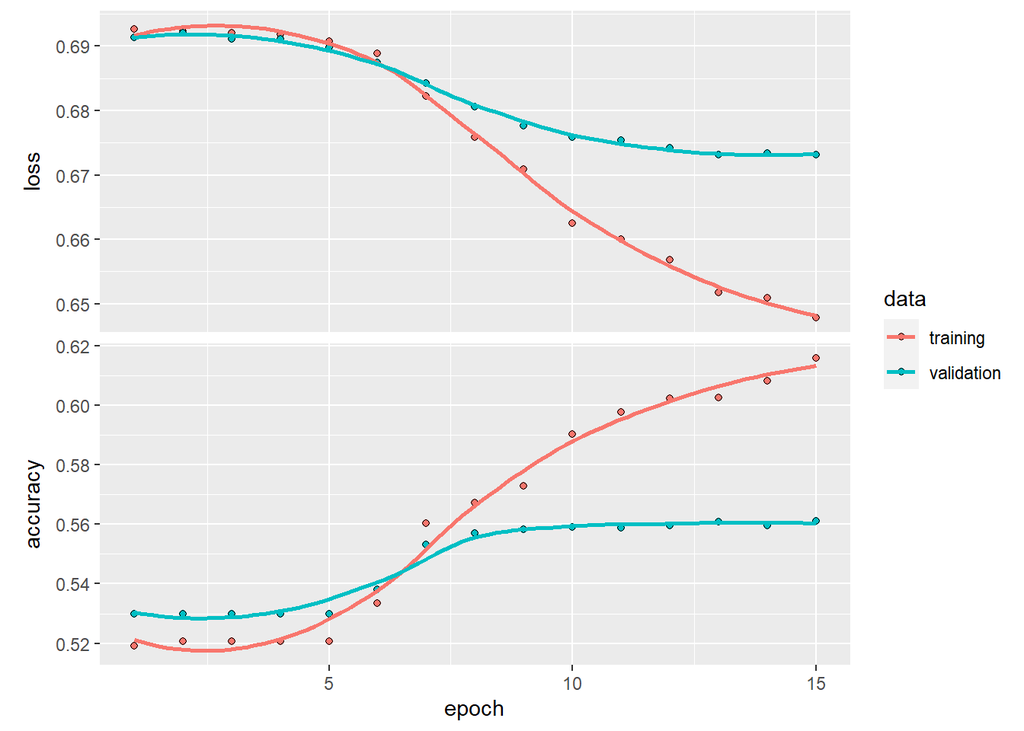

```r
plot(history)
```

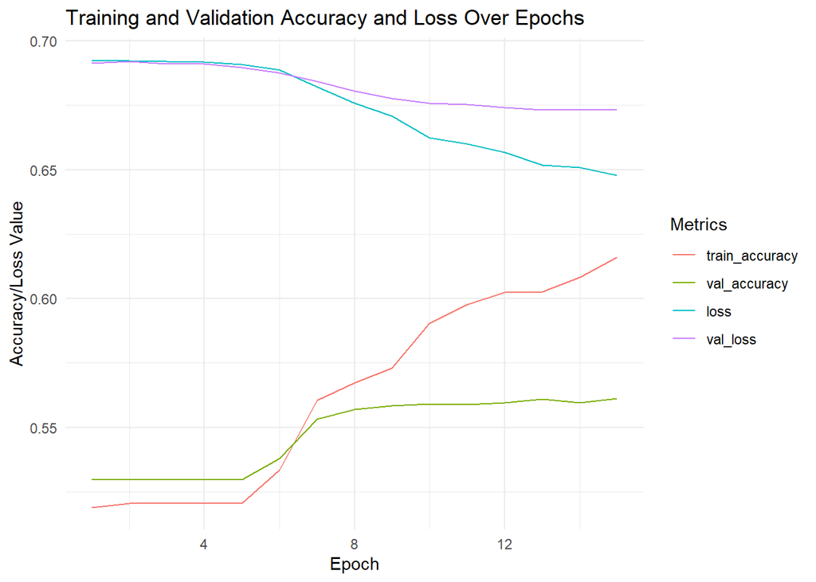

```r
# Extract training and validation metrics
train_metrics <- history$metrics$accuracy
val_metrics <- history$metrics$val_accuracy
loss <- history$metrics$loss
val_loss <- history$metrics$val_loss

metrics_df <- data.frame(
  epoch = 1:length(train_metrics),
  train_accuracy = train_metrics,
  val_accuracy = val_metrics,
  loss = loss,
  val_loss = val_loss
)
# Melt data frame for plotting
metrics_df <- melt(metrics_df, id.vars = "epoch")
# Plot accuracy & loss
accuracy_plot <- ggplot(metrics_df, aes(x = epoch, y = value, color = variable)) +
  geom_line() +
  labs(x = "Epoch", y = "Accuracy/Loss Value", color = "Metrics") +
  ggtitle("Training and Validation Accuracy and Loss Over Epochs") +
  theme_minimal()
# Print plot
print(accuracy_plot)
```

##### 4.

```r
# Test Results
metrics <- model %>% evaluate(
  test_data$word,
  as.numeric(test_data$score == "1")
)
validation_metrics <- model %>% evaluate(
  validation_data$word,
  as.numeric(validation_data$score == "1")
)
```

[output not shown]

I used the evaluate() function to compute the accuracy and loss values for the input data and labels. The input data is accessing the “word” column. The target variable is converted into numeric format, where each element will be 1 if the corresponding element in the “score” column is equal to 1.

## **Part V: Summary and Recommendations**

##### F.

The goal of my neural network is to predict user opinions based on previous reviews by classifying them as positive or negative. There was a total of 2983 customer reviews available to use as input for training my model. The dataset was partitioned into training, testing, and validation sets. The training set was used to train the model, while the validation set allowed me to adjust and monitor the model’s performance during training. Finally, the test set was utilized to evaluate the model’s performance on unseen data. Natural language processing allowed me to analyze the sentiments from the reviews, determining whether they were positive or negative. The model learned to associate the textual features of the reviews with the corresponding sentiment labels. While my model’s accuracy was not exceptionally high, the model was trained to distinguish the sentiment of new customer reviews.

##### G.

Although the model’s accuracy is not optimal, it is still better than chance. The model clearly needs to be improved before it can confidently be used in business decisions. We could experiment with different neural network architectures such as CNNs or LSTM networks. Hyperparameters such as learning rate, dropout rate, batch size, or optimizer algorithms could be fine-tuned.  
It is also possible the sources of the reviews should be examined. I am using reviews from three different sources: Yelp (business/restaurant reviews), IMDB (movies), and Amazon (products). These are three very different sources where customers might use different language to convey feelings; people might not speak about restaurants the same way they discuss movies.